# Introduction to the vnc R package

David Brown

## Load the vnc package

Load the package, as well as others that we’ll use in this vignette.

```r
library(vnc)
library(tidyverse)
library(dendextend)
library(ggdendro)
```

## Check the data

Let’s begin by looking at the frequencies of the bigram *witch hunt* and the plural *witch hunts*, which are available in the package data and come from Google Books.

```r
knitr::kable(witch_hunt, caption = "Data included with vnc package")
```

Data included with vnc package

| decade | token_count | total_count | counts_permil |
| --- | --- | --- | --- |
| 1600 | 3 | 1585485 | 1.89 |
| 1680 | 1 | 1945902 | 0.51 |
| 1810 | 4 | 499552970 | 0.01 |
| 1860 | 1 | 3247012381 | 0.00 |
| 1880 | 2 | 6267570245 | 0.00 |
| 1890 | 4 | 8293033235 | 0.00 |
| 1900 | 26 | 11103867317 | 0.00 |
| 1910 | 21 | 11777942915 | 0.00 |
| 1920 | 55 | 9964203621 | 0.01 |
| 1930 | 199 | 9067323416 | 0.02 |
| 1940 | 948 | 9673970472 | 0.10 |
| 1950 | 2639 | 13293905516 | 0.20 |
| 1960 | 3906 | 23660378418 | 0.17 |
| 1970 | 6379 | 29211995598 | 0.22 |
| 1980 | 6786 | 36463128334 | 0.19 |
| 1990 | 15064 | 58099277939 | 0.26 |
| 2000 | 29775 | 111276927919 | 0.27 |

## Periodization

The purpose of [Variability-Based Neighbor Clustering](https://www.oxfordhandbooks.com/view/10.1093/oxfordhb/9780199922765.001.0001/oxfordhb-9780199922765-e-14) is to divide the use of a word or phrase into historical periods based on changes in frequency. Rather than assuming that a year, decade, or other division is statistically meaningful, the algorithm clusters segments of time into periods.

For this to work, the time data that we input must be evenly spaced. There can’t be any gaps. In the data above, it is clear that there are many missing decades. If we tried to plot the data, a function called **is.sequence( )** would halt the process and produce an error.

```r
vnc_scree(witch_hunt$decade, witch_hunt$counts_permil, distance.measure = "sd")
```

```
#> Error in vnc_scree(witch_hunt$decade, witch_hunt$counts_permil, distance.measure = "sd"): It appears that your time series contains gaps or is not evenly spaced.
```

## Preparing the data

To prevent this error, we could fill in missing decades with zero counts. Alternatively, we can select only data from the twentieth century, which is what we will do here.

```r
wh_d <- witch_hunt %>%
  filter(decade > 1899) %>%
  dplyr::select(decade, counts_permil)
```

## Generate a scree plot

We will use the data to generate a scree plot. The platting function takes a vector of time intervals and a vector of values.

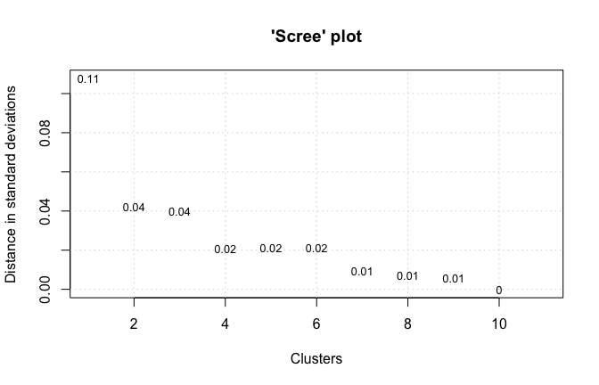

```r
vnc_scree(wh_d$decade, wh_d$counts_permil, distance.measure = "sd")
```

## Generate an hclust object

Next, we can generate an **hclust** object using the **vnc_clust( )** function. Like the **vnc_scree( )** function, it takes a vector of time intervals and a vector of values.

```r
hc <- vnc_clust(wh_d$decade, wh_d$counts_permil, distance.measure = "sd")
```

## Plot the dendrogram

A dendrogram can be plotted from the generated **hclust** object.

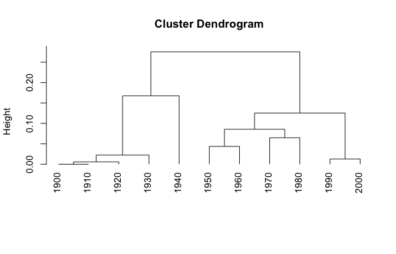

```r
plot(hc, hang = -1)
```

## Cut the dendrogram

For the next step, we’ll cut the dendrogram into 3 clusters based on the output of the scree plot we that generated. Note that we’re storing the output into an object **cut_hc**.

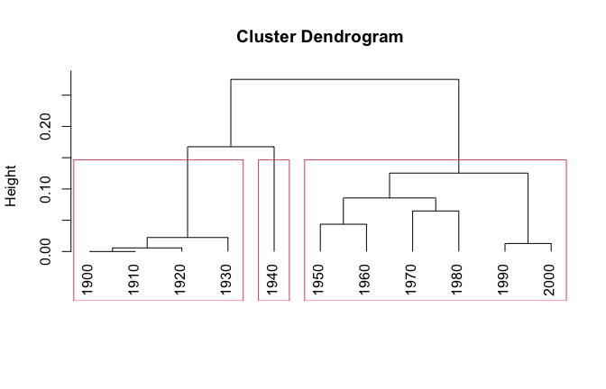

```r
plot(hc, hang = -1)
cut_hc <- rect.hclust(hc, k=3)
```

## Prepare data for fancier plotting

We’ve already plotted our data with base R. However, if we want more control, we probably want to use **ggplot2**. To do that, we need to go through a couple of intermediate steps. First, convert the **cut_hc** object that we just generated into a data.frame and join that with our original **wh_d** data.

```r
clust_df <- data.frame(decade=as.numeric(names(unlist(cut_hc))),
  clust=rep(c(paste0("clust_", seq(1:length(cut_hc)))),
  times=sapply(cut_hc,length)))

clust_df <- clust_df %>% right_join(wh_d, by = "decade")
```

And check the result…

```r
knitr::kable(clust_df)
```

| decade | clust | counts_permil |
| --- | --- | --- |
| 1900 | clust_1 | 0.00 |
| 1910 | clust_1 | 0.00 |
| 1920 | clust_1 | 0.01 |
| 1930 | clust_1 | 0.02 |
| 1940 | clust_2 | 0.10 |
| 1950 | clust_3 | 0.20 |
| 1960 | clust_3 | 0.17 |
| 1970 | clust_3 | 0.22 |
| 1980 | clust_3 | 0.19 |
| 1990 | clust_3 | 0.26 |
| 2000 | clust_3 | 0.27 |

Next, we’ll convert our cluster data into dendrogram data using **as.dendrogram( )** from [**ggdendro**](https://cran.r-project.org/web/packages/ggdendro/vignettes/ggdendro.html). We also MUST maintain the order of our time series. There are a variety of ways of doing this, but [**dendextend**](https://cran.r-project.org/web/packages/dendextend/vignettes/dendextend.html) has an easy function called **sort( )**. We’ll take the easy way!

To get ggplot-friendly data, we have to transform it yet again… This time using the **ggdendro** package’s function **dendro_data( )**.

```r
dend <- as.dendrogram(hc) %>% sort
dend_data <- dendro_data(dend, type = "rectangle")
```

Now let’s do some fancy plotting! We’re going to combine the dendrogram and a time series line plot like Gries and Hilpert do on pg. 140 of their chapter on VNC. The first three lines pull data from **clust_df** for the line plot using the clusters to color each point according to group. The **geom_segment** pulls data from **dend_data** to build the dendrogram. For the tick marks we again pull from **dend_data** using the **x** column for the breaks and and the **label** column to label the breaks.

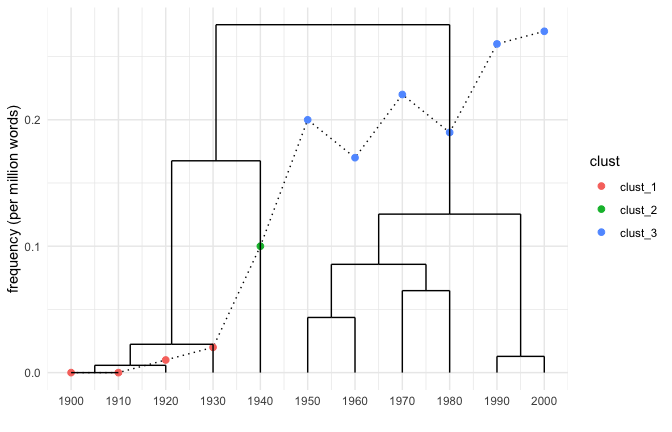

```r
ggplot(clust_df, aes(x = as.numeric(rownames(clust_df)), y = counts_permil)) +
  geom_line(linetype = "dotted") +
  geom_point(aes(color = clust), size = 2) +
  geom_segment(data = dend_data$segments, aes(x = x, y = y, xend = xend, yend = yend))+
  scale_x_continuous(breaks = dend_data$labels$x,
    labels=as.character(dend_data$labels$label)) +
  xlab("") + ylab("frequency (per million words)") +
  theme_minimal()
```

## Bibliography

Gries, Stefan Th, and Martin Hilpert. 2012. “Variability-Based Neighbor Clustering: A Bottom-up Approach to Periodization in Historical Linguistics.” *The Oxford Handbook of the History of English*, 134–44. https://www.oxfordhandbooks.com/view/10.1093/oxfordhb/9780199922765.001.0001/oxfordhb-9780199922765-e-14#oxfordhb-9780199922765-div1-50.

Gries, Stefan Th, and Sabine Stoll. 2009. “Finding Developmental Groups in Acquisition Data: Variability-Based Neighbour Clustering.” *Journal of Quantitative Linguistics* 16 (3): 217–42. https://www.tandfonline.com/doi/abs/10.1080/09296170902975692.

Th. Gries, Stefan, and Martin Hilpert. 2008. “The Identification of Stages in Diachronic Data: Variability-Based Neighbour Clustering.” *Corpora* 3 (1): 59–81. https://www.euppublishing.com/doi/abs/10.3366/E1749503208000075.